# Bayesian Statistics

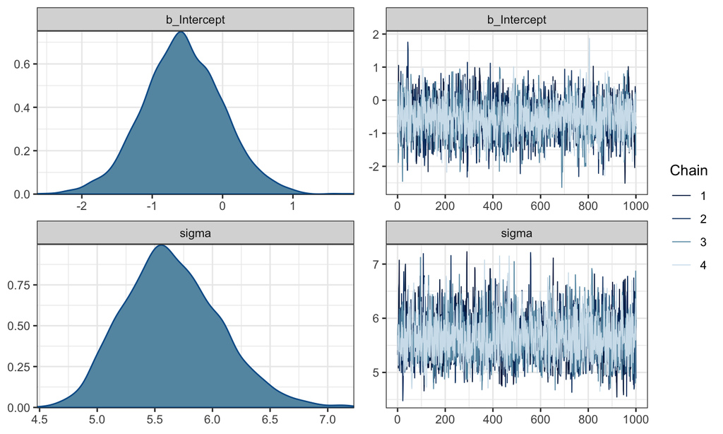

```r
library('brms')
m <- brm(
  x ~ 1, prior = prior(normal(0, 5), class = 'Intercept'), data = data.frame(x = x), refresh = 0
); plot(m)
```

## Posterior predictive checking

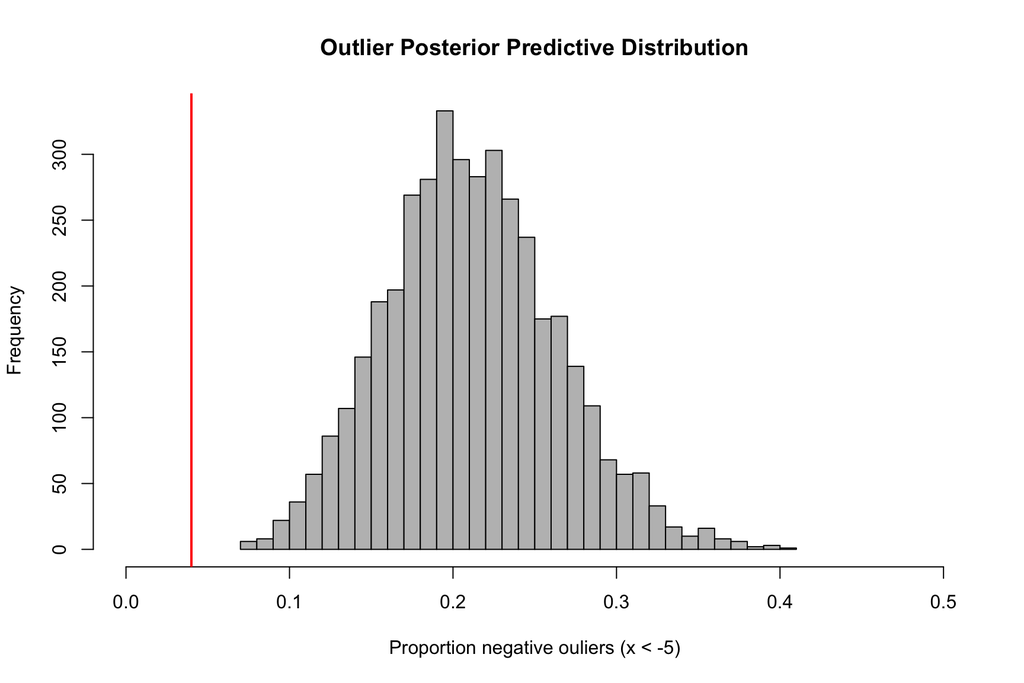

## Conclusion

- Bayesian inference uses probability to quantify uncertainty for **everything**
- Model comparison, parameter estimation, and model prediction are unified by Bayes’ rule

\[ \underbrace{p(\theta \mid y)}_{{\text{Posterior}}} = \frac{\overbrace{p(y \mid \theta)}^{\text{Likelihood}}\, \overbrace{p(\theta)}^{\text{Prior}}}{\underbrace{p(y)}_{\text{Marginal likelihood}}} = \frac{p(y \mid \theta) \, p(\theta)}{\int_{\Theta} p(y, \theta) \, \mathrm{d}\theta} \]

- Bayesian priors naturally regularize parameter estimates
- Bayes factors require careful prior specification (cf., Lindley’s paradox)
- Can test theoretically interesting hypotheses and compare non-nested models
- Not so important for parameter estimation, where the data tends to dominate
- Software for Bayesian inference:
  - [JAGS](http://mcmc-jags.sourceforge.net/), [Stan](https://mc-stan.org/)
  - Turing.jl, [PyMC3](https://docs.pymc.io/), greta, brms